# R Notebook

## Get the hurdel p-values

```r
dim(lrtlist[[1]]) # 14577 x 3 x 3
lrtlist[[1]][1, , ]
#  metric
# test.type   lambda df Pr(>Chisq)
#    cont   1.574313  1  0.2095818
#    disc   1.819781  1  0.1773394
#    hurdle 3.394094  2  0.1832238
lrtlist[[1]][1, , ][3,3] # 0.1832238

mast_pval_glm_list = lapply(lrtlist, FUN = function(lrt0) apply(lrt0, 1, function(x){x[3,3]}))
str(mast_pval_glm_list)

mast_pval_glm_df = as.data.frame(mast_pval_glm_list)
write.csv(mast_pval_glm_df, file = "MastGenePvals_by_CellType.csv", quote = FALSE)
```

List of 11  
$ G_1 : Named num [1:14577] 0.18322 0.63864 0.58685 0.00551 0.01007 …  
..- attr(, “names”)= chr [1:14577] “DPM1” “SCYL3” “C1orf112” “FGR” …  
$ G_2 : Named num [1:14577] 2.17e-37 6.36e-06 1.17e-05 5.19e-25 1.11e-52 …  
..- attr(, “names”)= chr [1:14577] “DPM1” “SCYL3” “C1orf112” “FGR” …  
$ G_3 : Named num [1:14577] 1.03e-01 2.64e-12 3.88e-57 0.00 1.30e-80 …  
..- attr(, “names”)= chr [1:14577] “DPM1” “SCYL3” “C1orf112” “FGR” …  
$ G_4 : Named num [1:14577] 4.81e-01 1.46e-01 3.20e-05 3.38e-08 7.41e-03 …  
..- attr(, “names”)= chr [1:14577] “DPM1” “SCYL3” “C1orf112” “FGR” …  
$ G_5 : Named num [1:14577] 3.92e-02 6.20e-01 3.65e-20 9.04e-70 4.85e-02 …  
..- attr(, “names”)= chr [1:14577] “DPM1” “SCYL3” “C1orf112” “FGR” …  
$ G_6 : Named num [1:14577] 7.23e-02 2.02e-02 9.94e-01 8.82e-42 1.03e-01 …  
..- attr(, “names”)= chr [1:14577] “DPM1” “SCYL3” “C1orf112” “FGR” …  
$ G_7 : Named num [1:14577] 2.59e-03 7.71e-03 1.01e-10 7.21e-69 3.89e-18 …  
..- attr(, “names”)= chr [1:14577] “DPM1” “SCYL3” “C1orf112” “FGR” …  
$ G_8 : Named num [1:14577] 5.73e-01 3.47e-02 1.50e-09 1.35e-10 2.51e-05 …  
..- attr(, “names”)= chr [1:14577] “DPM1” “SCYL3” “C1orf112” “FGR” …  
$ G_9 : Named num [1:14577] 7.25e-01 2.46e-05 4.00e-29 1.11e-68 2.72e-20 …  
..- attr(, “names”)= chr [1:14577] “DPM1” “SCYL3” “C1orf112” “FGR” …  
$ G_10: Named num [1:14577] 6.56e-03 1.43e-01 2.76e-02 9.00e-16 2.51e-04 …  
..- attr(, “names”)= chr [1:14577] “DPM1” “SCYL3” “C1orf112” “FGR” …  
$ G_11: Named num [1:14577] 4.61e-01 2.97e-01 9.50e-01 7.49e-09 2.06e-04 …  
..- attr(*, “names”)= chr [1:14577] “DPM1” “SCYL3” “C1orf112” “FGR” …

To downlowad the saved output, use  
`scp rcai2@bayes.biostat.washington.edu:/home/students/rcai2/IT-predictor/R/*by_CellType* /Users/cairuoyi/Documents/GitHub/IT-predictor/R/`

## Histogram of p-values

Dataframe of p-values for each comparison

```r
mast_pval_df = read.csv("MastGenePvals_by_CellType.csv", header = TRUE, row.names = 1)
head(mast_pval_df)
```

|  | G_1 | G_2 | G_3 | G_4 | G_5 | G_6 | G_7 | G_8 | G_9 | G_10 | G_11 |
| --- | --- | --- | --- | --- | --- | --- | --- | --- | --- | --- | --- |
| DPM1 | 0.183223804 | 2.169822e-37 | 1.025065e-01 | 4.812366e-01 | 3.921401e-02 | 7.225677e-02 | 2.594991e-03 | 5.728061e-01 | 7.253152e-01 | 6.562257e-03 | 4.605334e-01 |
| SCYL3 | 0.638641378 | 6.359677e-06 | 2.640596e-12 | 1.456617e-01 | 6.196719e-01 | 2.018583e-02 | 7.711062e-03 | 3.470588e-02 | 2.458700e-05 | 1.434269e-01 | 2.965283e-01 |
| C1orf112 | 0.586853404 | 1.165957e-05 | 3.883550e-57 | 3.195848e-05 | 3.648714e-20 | 9.944010e-01 | 1.010429e-10 | 1.503017e-09 | 3.999333e-29 | 2.758307e-02 | 9.501944e-01 |
| FGR | 0.005507162 | 5.185666e-25 | 0.000000e+00 | 3.376097e-08 | 9.039310e-70 | 8.815901e-42 | 7.209034e-69 | 1.351873e-10 | 1.113923e-68 | 9.004965e-16 | 7.490012e-09 |
| FUCA2 | 0.010068341 | 1.105890e-52 | 1.297501e-80 | 7.408532e-03 | 4.852703e-02 | 1.028462e-01 | 3.889286e-18 | 2.512494e-05 | 2.724304e-20 | 2.508264e-04 | 2.058354e-04 |
| GCLC | 0.721198401 | 2.302787e-01 | 4.155382e-03 | 3.273719e-02 | 2.299353e-01 | 5.495079e-02 | 3.849206e-02 | 1.461033e-01 | 6.306669e-02 | 1.420545e-03 | 9.739107e-01 |

Histogram of p-values for each comparison

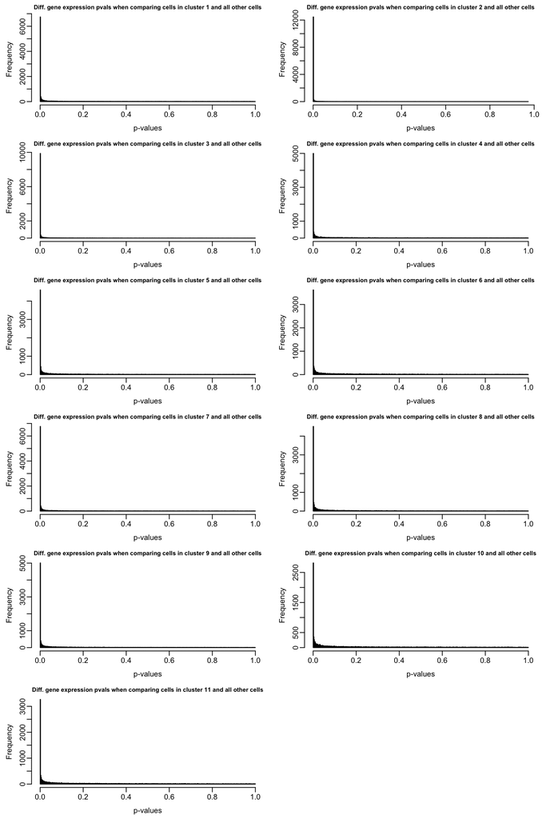

```r
par(mgp=c(2,0.5,0), mar=c(3.5,3.5,1.5,1), cex.main=0.8)
layout(matrix(1:12,nrow=6,ncol = 2,byrow = TRUE))
for (i in 1:11) {
  hist(mast_pval_df[,i], main = paste0("Diff. gene expression pvals when comparing cells in cluster ", i, " and all other cells"), xlab = "p-values", breaks = 500)
}
```

## Volcano plot of p-values for each comparison

Dataframe of fold changes

```r
fc_df = read.table("Average_GeneExpression_by_CellType.txt", header = TRUE)
head(fc_df)
```

|  | gene | u_1 | o_1 | fc_1 | u_2 | o_2 | fc_2 | u_3 | o_3 | fc_3 | u_4 | o_4 | fc_4 | u_5 | o_5 | fc_5 | u_6 | o_6 | fc_6 | u_7 | o_7 | fc_7 | u_8 | o_8 | fc_8 | u_9 | o_9 | fc_9 | u_10 | … |
| --- | --- | --- | --- | --- | --- | --- | --- | --- | --- | --- | --- | --- | --- | --- | --- | --- | --- | --- | --- | --- | --- | --- | --- | --- | --- | --- | --- | --- | --- | --- |
| 1 | DPM1 | 0.7799859 | 1.1948046 | 1.531828 | 1.05224138 | 1.1569697 | 1.0995288 | 2.1202312 | 1.0585695 | 0.49927080 | 1.8661091 | 1.1414281 | 0.6116620 | 0.98276466 | 1.1717023 | 1.1922512 | 0.66724295 | 1.1940978 | 1.7895998 | 1.4943392 | 1.0863945 | 0.7270066 | 0.7965265 | 1.2478558 | 1.566622 | 2.6861771 | 1.1053842 | 0.4115083 | 0.7884761 | … |
| 2 | SCYL3 | 0.3512315 | 0.3837586 | 1.092609 | 0.14248276 | 0.3853979 | 2.7048742 | 0.3272185 | 0.3859616 | 1.17952256 | 0.6526545 | 0.3754723 | 0.5753003 | 0.42695354 | 0.3761133 | 0.8809233 | 0.43550500 | 0.3762217 | 0.8638745 | 0.4975786 | 0.3570224 | 0.7175196 | 0.2700559 | 0.4093063 | 1.515636 | 0.8125270 | 0.3666606 | 0.4512596 | 0.2656647 | … |
| 3 | C1orf112 | 0.2443209 | 0.3831813 | 1.568353 | 0.05393103 | 0.3761517 | 6.9746803 | 0.3601939 | 0.3707897 | 1.02941689 | 0.1724727 | 0.3735705 | 2.1659688 | 0.61527037 | 0.3458928 | 0.5621801 | 0.21725205 | 0.3820873 | 1.7587282 | 0.5903586 | 0.3253095 | 0.5510371 | 0.1230956 | 0.4338137 | 3.524201 | 2.1082073 | 0.3135986 | 0.1487513 | 0.1657331 | … |
| 4 | FGR | 0.8549683 | 1.0076527 | 1.178585 | 0.07648276 | 1.0113164 | 13.2228017 | 6.0892095 | 0.4843324 | 0.07953945 | 0.4846545 | 1.0026093 | 2.0687092 | 0.04208682 | 1.0856996 | 25.7966636 | 0.04020928 | 1.0695226 | 26.5988986 | 0.4124778 | 1.1101545 | 2.6914283 | 0.4081268 | 1.1446387 | 2.804615 | 0.2765011 | 1.0161450 | 3.6750129 | 1.0388492 | … |
| 5 | FUCA2 | 0.2992681 | 0.8054739 | 2.691479 | 1.52196552 | 0.7414786 | 0.4871849 | 3.2265548 | 0.5102977 | 0.15815560 | 0.7924000 | 0.7561205 | 0.9542157 | 0.81405941 | 0.7512114 | 0.9227968 | 0.34712466 | 0.7897119 | 2.2750096 | 0.6305560 | 0.7822798 | 1.2406190 | 0.2544430 | 0.8870718 | 3.486328 | 1.3704320 | 0.7369470 | 0.5377480 | 0.4131477 | … |
| 6 | GCLC | 0.2271217 | 0.2902718 | 1.278045 | 0.22075862 | 0.2854690 | 1.2931275 | 0.4741834 | 0.2652374 | 0.55935614 | 0.5692000 | 0.2787946 | 0.4898009 | 0.25546078 | 0.2870016 | 1.1234665 | 0.16362147 | 0.2938873 | 1.7961412 | 0.2592828 | 0.2892290 | 1.1154960 | 0.2632468 | 0.2896327 | 1.100233 | 0.3282721 | 0.2827735 | 0.8613997 | 0.3088282 | … |

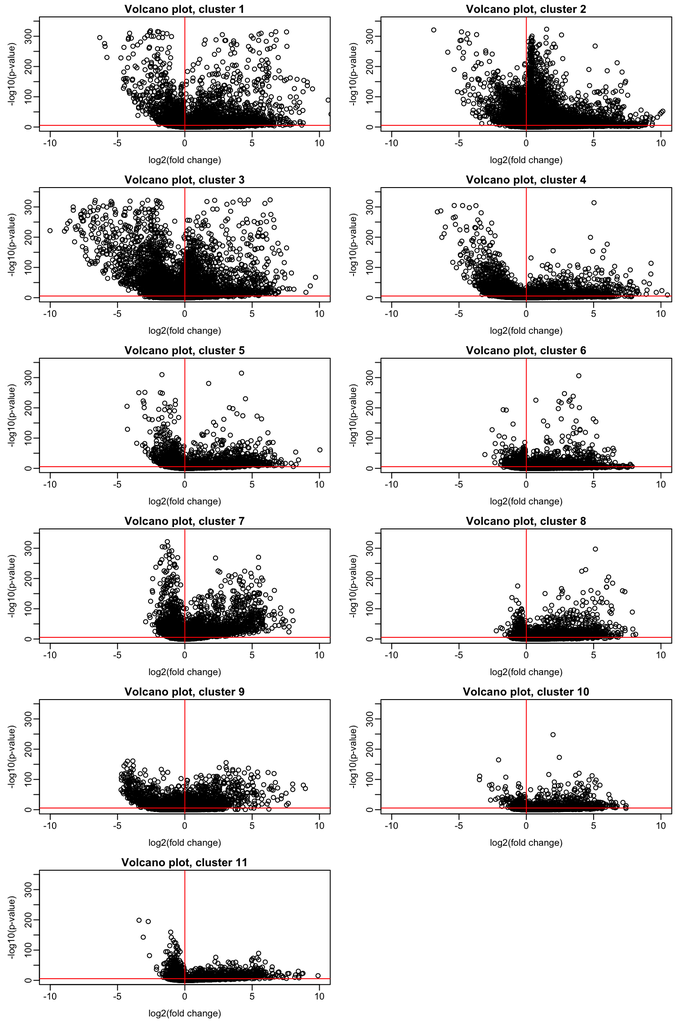

```r
par(mgp=c(2,0.5,0), mar=c(3.5,3.5,1.5,1))
layout(matrix(1:12,nrow=6,ncol = 2,byrow = TRUE))
for (i in 1:11) {
  plot(log2(fc_df[,paste0("fc_",i)]), -log10(mast_pval_df[,i]), main = paste0("Volcano plot, cluster ", i), xlab = "log2(fold change)", ylab = "-log10(p-value)", xlim = c(-10,10), ylim = c(0, 350))
  abline(h=-log10(3.408781e-06),col="red")
  abline(v=log2(1),col="red")
}
```

# Select differentially expressed genes for each cell type

Select around 60 genes per cell type. Select those genes with smallest p-value and fold change, by scanning a series of percentiles. For example, for 1 percentile, we select the intersection of the genes with p-value < 1 percentile and fold change smaller than 1 percentile. Choose the percentile that gives use between 55 and 65 genes.

```r
for (i in 1:11) {
  print(length(fc_df$gene[fc_df[,paste0("fc_",i)] <= quantile(fc_df[,paste0("fc_",i)],probs=seq(0,0.1,0.01))[4] & mast_pval_df[,i] <= quantile(mast_pval_df[,i],probs=seq(0,0.1,0.01))[4]]))
}
```

```
## [1] 201
## [1] 87
## [1] 233
## [1] 227
## [1] 162
## [1] 69
## [1] 92
## [1] 75
## [1] 147
## [1] 97
## [1] 115
```

```r
length(fc_df$gene[fc_df[,paste0("fc_",i)] <= quantile(fc_df[,paste0("fc_",i)],probs=0.027) & mast_pval_df[,i] <= quantile(mast_pval_df[,i],probs=0.027)])
```

```
## [1] 101
```

```r
genes.selected.perCellType = list()

quantiles = c(0.009, 0.022, 0.007, 0.007, 0.012, 0.027, 0.021, 0.027, 0.013, 0.02, 0.018)

for (i in 1:11) {
  genes.selected.perCellType[[colnames(mast_pval_df)[i]]] = as.character(fc_df$gene[fc_df[,paste0("fc_",i)] <= quantile(fc_df[,paste0("fc_",i)],probs=quantiles[i]) & mast_pval_df[,i] <= quantile(mast_pval_df[,i],probs=quantiles[i])])
}

genes.selected.perCellType
```

```
## $G_1
##  [1] "CD79B"         "BTK"           "CD22"          "STAP1"
##  [5] "ADAM28"        "MEF2C"         "COL19A1"       "BLNK"
##  [9] "TCL1A"         "CD40"          "KIAA0226L"     "FCER2"
## [13] "CD79A"         "POU2AF1"       "RALGPS2"       "CR2"
## [17] "BCL11A"        "HVCN1"         "VPREB3"        "WDFY4"
## [21] "NAPSB"         "FCRLA"         "FCRL2"         "SWAP70"
## [25] "BLK"           "ARHGAP24"      "AFF3"          "BANK1"
## [29] "MS4A1"         "NCF1"          "CXCR5"         "FCRL1"
## [33] "SMIM14"        "EBF1"          "NCF1C"         "FAM129C"
## [37] "PKIG"          "TLR10"         "CD19"          "CLEC17A"
## [41] "CNR2"          "PAX5"          "TCF4"          "RP11-693J15.5"
## [45] "IGKC"          "IGLC3"         "IGHG2"         "IGHG1"
## [49] "IGHG3"         "IGHD"          "IGHM"          "AC096579.7"
## [53] "HLA-DOB"       "LINC00926"     "IGHGP"         "CTA-250D10.23"
```

[output cut: 177 more lines]

Check how many genes are selected by more than one cell type

```r
selected.genes = unlist(genes.selected.perCellType, use.names = FALSE) # 666 genes in total
selected.genes[duplicated(selected.genes)] # 101 genes are selected in more than 1 cell type
```

```
##   [1] "BLNK"          "CD79A"         "POU2AF1"       "IGKC"
##   [5] "IGHG2"         "IGHG1"         "IGHG3"         "AC096579.7"
##   [9] "IGHGP"         "DERL3"         "TCL1A"         "GAB1"
##  [13] "NAPSB"         "IGJ"           "FAM129C"       "GNG7"
##  [17] "TCF4"          "AC096579.7"    "SPIB"          "CD4"
##  [21] "FBLN7"         "MAL"           "CD28"          "CCR4"
##  [25] "ESPN"          "TNFRSF25"      "MGAT4A"        "TCF7"
##  [29] "GZMH"          "NKG7"          "CRTAM"         "KLRD1"
##  [33] "CAMK4"         "CD8A"          "TC2N"          "IL7R"
##  [37] "CD8B"          "CTSW"          "THEMIS"        "KLRC4"
##  [41] "KLRK1"         "ITGA1"         "CD8BP"         "KLRC4-KLRK1"
##  [45] "RP11-291B21.2" "TXK"           "FOSL2"         "RNF125"
##  [49] "KLRB1"         "ANXA1"         "AOAH"          "SORL1"
##  [53] "STAT4"         "GZMA"          "DHRS3"         "SYTL3"
##  [57] "IL7R"          "S1PR1"         "HOPX"          "A2M"
##  [61] "C20orf112"     "CD38"          "IKZF2"         "TNFRSF9"
##  [65] "RAB27A"        "SIRPG"         "LAG3"          "GZMH"
##  [69] "GZMB"          "NKG7"          "CRTAM"         "IFNG"
##  [73] "GZMK"          "GNLY"          "FASLG"         "HAVCR2"
##  [77] "OASL"          "CHST12"        "KLRG1"         "SNAP47"
##  [81] "GZMA"          "JAKMIP1"       "CXCL13"        "CCR5"
##  [85] "VCAM1"         "EOMES"         "SAMD3"         "AFAP1L2"
##  [89] "CXCR6"         "PRF1"          "F2R"           "TIGIT"
##  [93] "RTKN2"         "PDCD1"         "NCR1"          "TRGC1"
##  [97] "TRDC"          "AC069363.1"    "AC092580.4"    "CTD-2313F11.1"
## [101] "AE000661.37"
```

Save the output

```r
for (i in 1:11) {
  sig_gene = genes.selected.perCellType[[i]]
  sig_gene_expression = fc_df[,paste0("u_",i)][match(sig_gene,as.character(fc_df$gene))]
  signature_gene_df = data.frame(avg.expression = sig_gene_expression)
  rownames(signature_gene_df) = sig_gene
  write.csv(signature_gene_df, file = paste0("./Signature_gene_expression/cluster", i, ".csv"), quote = FALSE)
}
```

```r
gc()
```

```
##           used (Mb) gc trigger (Mb) limit (Mb) max used (Mb)
## Ncells  573232 30.7    1486204 79.4         NA  1486204 79.4
## Vcells 2267563 17.4    8388608 64.0      16384  8378857 64.0
```